# Project 1: SAT & ACT Analysis

### Contents:

- 2017 Data Import & Cleaning
- 2018 Data Import and Cleaning
- Exploratory Data Analysis
- Data Visualization
- Conclusions and Recommendations

## 2017 Data Import and Cleaning

```python
import numpy as np
import pandas as pd
```

#### 1. Read In SAT & ACT Data

Read in the `sat_2017.csv` and `act_2017.csv` files and assign them to appropriately named pandas dataframes.

```python
sat_2017 = '../data/sat_2017.csv'
act_2017 = '../data/act_2017.csv'

with open(sat_2017, mode="r") as sat17:
    sat17 = pd.read_csv(sat17)

with open(act_2017, mode="r") as act17:
    act17 = pd.read_csv(act17)
```

#### 2. Display Data

Print the first 10 rows of each dataframe to your jupyter notebook

```python
sat17.head(10)
```

|  | State | Participation | Evidence-Based Reading and Writing | Math | Total |
| --- | --- | --- | --- | --- | --- |
| 0 | Alabama | 5% | 593 | 572 | 1165 |
| 1 | Alaska | 38% | 547 | 533 | 1080 |
| 2 | Arizona | 30% | 563 | 553 | 1116 |
| 3 | Arkansas | 3% | 614 | 594 | 1208 |
| 4 | California | 53% | 531 | 524 | 1055 |
| 5 | Colorado | 11% | 606 | 595 | 1201 |
| 6 | Connecticut | 100% | 530 | 512 | 1041 |
| 7 | Delaware | 100% | 503 | 492 | 996 |
| 8 | District of Columbia | 100% | 482 | 468 | 950 |
| 9 | Florida | 83% | 520 | 497 | 1017 |

```python
act17.head(10)
```

|  | State | Participation | English | Math | Reading | Science | Composite |
| --- | --- | --- | --- | --- | --- | --- | --- |
| 0 | National | 60% | 20.3 | 20.7 | 21.4 | 21.0 | 21.0 |
| 1 | Alabama | 100% | 18.9 | 18.4 | 19.7 | 19.4 | 19.2 |
| 2 | Alaska | 65% | 18.7 | 19.8 | 20.4 | 19.9 | 19.8 |
| 3 | Arizona | 62% | 18.6 | 19.8 | 20.1 | 19.8 | 19.7 |
| 4 | Arkansas | 100% | 18.9 | 19.0 | 19.7 | 19.5 | 19.4 |
| 5 | California | 31% | 22.5 | 22.7 | 23.1 | 22.2 | 22.8 |
| 6 | Colorado | 100% | 20.1 | 20.3 | 21.2 | 20.9 | 20.8 |
| 7 | Connecticut | 31% | 25.5 | 24.6 | 25.6 | 24.6 | 25.2 |
| 8 | Delaware | 18% | 24.1 | 23.4 | 24.8 | 23.6 | 24.1 |
| 9 | District of Columbia | 32% | 24.4 | 23.5 | 24.9 | 23.5 | 24.2 |

#### 3. Verbally Describe Data

Take your time looking through the data and thoroughly describe the data in the markdown cell below.

```python
sat17.describe()
```

|  | Evidence-Based Reading and Writing | Math | Total |
| --- | --- | --- | --- |
| count | 51.000000 | 51.000000 | 51.000000 |
| mean | 569.117647 | 547.627451 | 1126.098039 |
| std | 45.666901 | 84.909119 | 92.494812 |
| min | 482.000000 | 52.000000 | 950.000000 |
| 25% | 533.500000 | 522.000000 | 1055.500000 |
| 50% | 559.000000 | 548.000000 | 1107.000000 |
| 75% | 613.000000 | 599.000000 | 1212.000000 |
| max | 644.000000 | 651.000000 | 1295.000000 |

```python
act17.describe()
```

|  | English | Math | Reading | Science |
| --- | --- | --- | --- | --- |
| count | 52.000000 | 52.000000 | 52.000000 | 52.000000 |
| mean | 20.919231 | 21.173077 | 22.001923 | 21.040385 |
| std | 2.332132 | 1.963602 | 2.048672 | 3.151113 |
| min | 16.300000 | 18.000000 | 18.100000 | 2.300000 |
| 25% | 19.000000 | 19.400000 | 20.475000 | 19.900000 |
| 50% | 20.550000 | 20.900000 | 21.700000 | 21.150000 |
| 75% | 23.300000 | 23.100000 | 24.125000 | 22.525000 |
| max | 25.500000 | 25.300000 | 26.000000 | 24.900000 |

Answer:

#### 4a. Does the data look complete?

Answer:

Knowing that in the USA, there are 50 states plus 1 Washington DC District. There should be only 51 mentioned 'states' in both ACT and SAT results. ACT has an additional 1 count, on further investigation, it seemed to be the consolidation of National results. This would be dropped as each row should represent results from individual states.

#### 4b. Are there any obvious issues with the observations?

**What is the minimum *possible* value for each test/subtest? What is the maximum *possible* value?**

Consider comparing any questionable values to the sources of your data:

- [SAT](https://blog.collegevine.com/here-are-the-average-sat-scores-by-state/)
- [ACT](https://blog.prepscholar.com/act-scores-by-state-averages-highs-and-lows)

Answer:

Checked with source for SAT 2017 and ACT2017, seemed that there were some errors with csv raw data.

#### 4c. Fix any errors you identified

**The data is available** so there's no need to guess or calculate anything. If you didn't find any errors, continue to the next step.

```python
# Utilising masking to replace errors in csv raw data.
sat17.loc[(sat17.State == "Maryland") & (sat17.Participation == "69%") & (sat17.Total == 1060), "Math"] = 524
act17.loc[(act17.State == "Maryland") & (act17.Participation == "28%") & (act17.Composite == "23.6"), "Science"] = 23.2
act17.loc[(act17.State == "Wyoming") & (act17.Participation == "100%") & (act17.English == 19.4), "Composite"] = 20.2
```

```python
sat17.describe()
```

|  | Evidence-Based Reading and Writing | Math | Total |
| --- | --- | --- | --- |
| count | 51.000000 | 51.000000 | 51.000000 |
| mean | 569.117647 | 556.882353 | 1126.098039 |
| std | 45.666901 | 47.121395 | 92.494812 |
| min | 482.000000 | 468.000000 | 950.000000 |
| 25% | 533.500000 | 523.500000 | 1055.500000 |
| 50% | 559.000000 | 548.000000 | 1107.000000 |
| 75% | 613.000000 | 599.000000 | 1212.000000 |
| max | 644.000000 | 651.000000 | 1295.000000 |

```python
act17.describe()
```

|  | English | Math | Reading | Science |
| --- | --- | --- | --- | --- |
| count | 52.000000 | 52.000000 | 52.000000 | 52.000000 |
| mean | 20.919231 | 21.173077 | 22.001923 | 21.442308 |
| std | 2.332132 | 1.963602 | 2.048672 | 1.723351 |
| min | 16.300000 | 18.000000 | 18.100000 | 18.200000 |
| 25% | 19.000000 | 19.400000 | 20.475000 | 19.975000 |
| 50% | 20.550000 | 20.900000 | 21.700000 | 21.300000 |
| 75% | 23.300000 | 23.100000 | 24.125000 | 23.200000 |
| max | 25.500000 | 25.300000 | 26.000000 | 24.900000 |

#### 5. What are your data types?

Display the data types of each feature.

```python
sat17.dtypes
```

```
State                                 object
Participation                         object
Evidence-Based Reading and Writing     int64
Math                                   int64
Total                                  int64
dtype: object
```

```python
act17.dtypes
```

```
State             object
Participation     object
English          float64
Math             float64
Reading          float64
Science          float64
Composite         object
dtype: object
```

What did you learn?

- Do any of them seem odd?
- Which ones are not as they should be?

Answer:

Participation rates for ACT and SAT 2017, and Composite from ACT 2017 shld be either float or int data type

#### 6. Fix Incorrect Data Types

Based on what you discovered above, use appropriate methods to re-type incorrectly typed data.

- Define a function that will allow you to convert participation rates to an appropriate numeric type. Use `map` or `apply` to change these columns in each dataframe.

```python
def coerce_df_columns_to_numeric(df, column_list):
    df[column_list] = df[column_list].apply(pd.to_numeric, errors='coerce')
    return df
```

- Fix any individual values preventing other columns from being the appropriate type.

```python
# To remove '%' from the last character in Participation column
sat17["Participation"] = [x[:-1] for x in sat17["Participation"]]
act17["Participation"] = [x[:-1] for x in act17["Participation"]]
```

- Finish your data modifications by making sure the columns are now typed appropriately.

```python
# To convert string data type to either int or float
coerce_df_columns_to_numeric(sat17, "Participation")
coerce_df_columns_to_numeric(act17, ["Participation", "Composite"])
```

|  | State | Participation | English | Math | Reading | Science | Composite |
| --- | --- | --- | --- | --- | --- | --- | --- |
| 0 | National | 60 | 20.3 | 20.7 | 21.4 | 21.0 | 21.0 |
| 1 | Alabama | 100 | 18.9 | 18.4 | 19.7 | 19.4 | 19.2 |
| 2 | Alaska | 65 | 18.7 | 19.8 | 20.4 | 19.9 | 19.8 |
| 3 | Arizona | 62 | 18.6 | 19.8 | 20.1 | 19.8 | 19.7 |
| 4 | Arkansas | 100 | 18.9 | 19.0 | 19.7 | 19.5 | 19.4 |
| 5 | California | 31 | 22.5 | 22.7 | 23.1 | 22.2 | 22.8 |
| 6 | Colorado | 100 | 20.1 | 20.3 | 21.2 | 20.9 | 20.8 |
| 7 | Connecticut | 31 | 25.5 | 24.6 | 25.6 | 24.6 | 25.2 |
| 8 | Delaware | 18 | 24.1 | 23.4 | 24.8 | 23.6 | 24.1 |
| 9 | District of Columbia | 32 | 24.4 | 23.5 | 24.9 | 23.5 | 24.2 |
| 10 | Florida | 73 | 19.0 | 19.4 | 21.0 | 19.4 | 19.8 |
| 11 | Georgia | 55 | 21.0 | 20.9 | 22.0 | 21.3 | 21.4 |
| 12 | Hawaii | 90 | 17.8 | 19.2 | 19.2 | 19.3 | 19.0 |
| 13 | Idaho | 38 | 21.9 | 21.8 | 23.0 | 22.1 | 22.3 |
| 14 | Illinois | 93 | 21.0 | 21.2 | 21.6 | 21.3 | 21.4 |
| 15 | Indiana | 35 | 22.0 | 22.4 | 23.2 | 22.3 | 22.6 |
| 16 | Iowa | 67 | 21.2 | 21.3 | 22.6 | 22.1 | 21.9 |
| 17 | Kansas | 73 | 21.1 | 21.3 | 22.3 | 21.7 | 21.7 |
| 18 | Kentucky | 100 | 19.6 | 19.4 | 20.5 | 20.1 | 20.0 |
| 19 | Louisiana | 100 | 19.4 | 18.8 | 19.8 | 19.6 | 19.5 |
| 20 | Maine | 8 | 24.2 | 24.0 | 24.8 | 23.7 | 24.3 |
| 21 | Maryland | 28 | 23.3 | 23.1 | 24.2 | 23.2 | 23.6 |
| 22 | Massachusetts | 29 | 25.4 | 25.3 | 25.9 | 24.7 | 25.4 |
| 23 | Michigan | 29 | 24.1 | 23.7 | 24.5 | 23.8 | 24.1 |
| 24 | Minnesota | 100 | 20.4 | 21.5 | 21.8 | 21.6 | 21.5 |
| 25 | Mississippi | 100 | 18.2 | 18.1 | 18.8 | 18.8 | 18.6 |
| 26 | Missouri | 100 | 19.8 | 19.9 | 20.8 | 20.5 | 20.4 |
| 27 | Montana | 100 | 19.0 | 20.2 | 21.0 | 20.5 | 20.3 |
| 28 | Nebraska | 84 | 20.9 | 20.9 | 21.9 | 21.5 | 21.4 |
| 29 | Nevada | 100 | 16.3 | 18.0 | 18.1 | 18.2 | 17.8 |
| 30 | New Hampshire | 18 | 25.4 | 25.1 | 26.0 | 24.9 | 25.5 |
| 31 | New Jersey | 34 | 23.8 | 23.8 | 24.1 | 23.2 | 23.9 |
| 32 | New Mexico | 66 | 18.6 | 19.4 | 20.4 | 20.0 | 19.7 |
| 33 | New York | 31 | 23.8 | 24.0 | 24.6 | 23.9 | 24.2 |
| 34 | North Carolina | 100 | 17.8 | 19.3 | 19.6 | 19.3 | 19.1 |
| 35 | North Dakota | 98 | 19.0 | 20.4 | 20.5 | 20.6 | 20.3 |
| 36 | Ohio | 75 | 21.2 | 21.6 | 22.5 | 22.0 | 22.0 |
| 37 | Oklahoma | 100 | 18.5 | 18.8 | 20.1 | 19.6 | 19.4 |
| 38 | Oregon | 40 | 21.2 | 21.5 | 22.4 | 21.7 | 21.8 |
| 39 | Pennsylvania | 23 | 23.4 | 23.4 | 24.2 | 23.3 | 23.7 |
| 40 | Rhode Island | 21 | 24.0 | 23.3 | 24.7 | 23.4 | 24.0 |
| 41 | South Carolina | 100 | 17.5 | 18.6 | 19.1 | 18.9 | 18.7 |
| 42 | South Dakota | 80 | 20.7 | 21.5 | 22.3 | 22.0 | 21.8 |
| 43 | Tennessee | 100 | 19.5 | 19.2 | 20.1 | 19.9 | 19.8 |
| 44 | Texas | 45 | 19.5 | 20.7 | 21.1 | 20.9 | 20.7 |
| 45 | Utah | 100 | 19.5 | 19.9 | 20.8 | 20.6 | 20.3 |
| 46 | Vermont | 29 | 23.3 | 23.1 | 24.4 | 23.2 | 23.6 |
| 47 | Virginia | 29 | 23.5 | 23.3 | 24.6 | 23.5 | 23.8 |
| 48 | Washington | 29 | 20.9 | 21.9 | 22.1 | 22.0 | 21.9 |
| 49 | West Virginia | 69 | 20.0 | 19.4 | 21.2 | 20.5 | 20.4 |
| 50 | Wisconsin | 100 | 19.7 | 20.4 | 20.6 | 20.9 | 20.5 |
| 51 | Wyoming | 100 | 19.4 | 19.8 | 20.8 | 20.6 | 20.2 |

```python
# To represent Participation rates to percentages value with 100% being 1.00
sat17["Participation"] = [x/100 for x in sat17["Participation"]]
act17["Participation"] = [x/100 for x in act17["Participation"]]
```

- Display the data types again to confirm they are correct.

```python
act17.describe()
```

|  | Participation | English | Math | Reading | Science | Composite |
| --- | --- | --- | --- | --- | --- | --- |
| count | 52.000000 | 52.000000 | 52.000000 | 52.000000 | 52.000000 | 52.000000 |
| mean | 0.651538 | 20.919231 | 21.173077 | 22.001923 | 21.442308 | 21.509615 |
| std | 0.318325 | 2.332132 | 1.963602 | 2.048672 | 1.723351 | 2.002083 |
| min | 0.080000 | 16.300000 | 18.000000 | 18.100000 | 18.200000 | 17.800000 |
| 25% | 0.310000 | 19.000000 | 19.400000 | 20.475000 | 19.975000 | 19.800000 |
| 50% | 0.680000 | 20.550000 | 20.900000 | 21.700000 | 21.300000 | 21.400000 |
| 75% | 1.000000 | 23.300000 | 23.100000 | 24.125000 | 23.200000 | 23.600000 |
| max | 1.000000 | 25.500000 | 25.300000 | 26.000000 | 24.900000 | 25.500000 |

#### 7. Rename Columns

Change the names of the columns to more expressive names so that you can tell the difference the SAT columns and the ACT columns. Your solution should map all column names being changed at once (no repeated singular name-changes). **We will be combining these data with some of the data from 2018, and so you should name columns in an appropriate way**.

**Guidelines**:

- Column names should be all lowercase (you will thank yourself when you start pushing data to SQL later in the course)
- Column names should not contain spaces (underscores will suffice--this allows for using the `df.column_name` method to access columns in addition to `df['column_name']`.
- Column names should be unique and informative (the only feature that we actually share between dataframes is the state).

```python
# To change column names to all lowercase, and identification from Test and Year
sat17.columns = ['state', 'participation_s17', 'erw_s17', 'math_s17', 'total_s17']
act17.columns = ['state', 'participation_a17', 'eng_a17', 'math_a17', 'readg_a17', 'science_a17', 'composite_a17']
```

```python
act17.dtypes
```

```
state                 object
participation_a17    float64
eng_a17              float64
math_a17             float64
readg_a17            float64
science_a17          float64
composite_a17        float64
dtype: object
```

#### 8. Create a data dictionary

Now that we've fixed our data, and given it appropriate names, let's create a [data dictionary](http://library.ucmerced.edu/node/10249).

A data dictionary provides a quick overview of features/variables/columns, alongside data types and descriptions. The more descriptive you can be, the more useful this document is.

Example of a Fictional Data Dictionary Entry:

| Feature | Type | Dataset | Description |
| --- | --- | --- | --- |
| **county_pop** | *integer* | 2010 census | The population of the county (units in thousands, where 2.5 represents 2500 people). |
| **per_poverty** | *float* | 2010 census | The percent of the county over the age of 18 living below the 200% of official US poverty rate (units percent to two decimal places 98.10 means 98.1%) |

[Here's a quick link to a short guide for formatting markdown in Jupyter notebooks](https://jupyter-notebook.readthedocs.io/en/stable/examples/Notebook/Working%20With%20Markdown%20Cells.html).

Provided is the skeleton for formatting a markdown table, with columns headers that will help you create a data dictionary to quickly summarize your data, as well as some examples. **This would be a great thing to copy and paste into your custom README for this project.**

| Feature | Type | Dataset | Description |
| --- | --- | --- | --- |
| column name | int/float/object | ACT/SAT | This is an example |

##### SAT Data Dictionary

| Feature | Type | Dataset | Description |
| --- | --- | --- | --- |
| state_s17 | object | SAT | Respective states in the USA taking SAT test in 2017 |
| participation_s17 | float | SAT | Participation rate of high school graduates taking SAT test in 2017 |
| erw_s17 | int | SAT | Average English-Reading-Writing scores in the state |
| math_s17 | int | SAT | Average Math scores in the state |
| total_s17 | int | SAT | Average Total scores in the state |

##### ACT Data Dictionary

| Feature | Type | Dataset | Description |
| --- | --- | --- | --- |
| state_a17 | object | ACT | Respective states in the USA taking SAT test in 2017 |
| participation_a17 | float | ACT | Participation rate of high school graduates taking ACT test in 2017 |
| eng_a17 | float | ACT | Average Engish scores in the state |
| math_a17 | float | ACT | Average Math scores in the state |
| readg_a17 | float | ACT | Average Reading scores in the state |
| science_a17 | float | ACT | Average Science scores in the state |
| composite_a17 | float | ACT | Average Total scores in the state |

#### 9. Drop unnecessary rows

One of our dataframes contains an extra row. Identify and remove this from the dataframe.

```python
# Set index to 'state' col in order to drop row with index 'National'
act17 = act17.set_index("state")
act17 = act17.drop("National", axis=0)
```

```python
act17.describe()
```

|  | participation_a17 | eng_a17 | math_a17 | readg_a17 | science_a17 | composite_a17 |
| --- | --- | --- | --- | --- | --- | --- |
| count | 51.000000 | 51.000000 | 51.000000 | 51.000000 | 51.000000 | 51.000000 |
| mean | 0.652549 | 20.931373 | 21.182353 | 22.013725 | 21.450980 | 21.519608 |
| std | 0.321408 | 2.353677 | 1.981989 | 2.067271 | 1.739353 | 2.020695 |
| min | 0.080000 | 16.300000 | 18.000000 | 18.100000 | 18.200000 | 17.800000 |
| 25% | 0.310000 | 19.000000 | 19.400000 | 20.450000 | 19.950000 | 19.800000 |
| 50% | 0.690000 | 20.700000 | 20.900000 | 21.800000 | 21.300000 | 21.400000 |
| 75% | 1.000000 | 23.300000 | 23.100000 | 24.150000 | 23.200000 | 23.600000 |
| max | 1.000000 | 25.500000 | 25.300000 | 26.000000 | 24.900000 | 25.500000 |

#### 10. Merge Dataframes

Join the 2017 ACT and SAT dataframes using the state in each dataframe as the key. Assign this to a new variable.

```python
combine_17 = sat17.join(act17, on="state") # Joing sat17 and act17, by using index 'state'
```

#### 11. Save your cleaned, merged dataframe

Use a relative path to save out your data as `combined_2017.csv`.

```python
# combine_17.to_csv('../data/combine_2017.csv', index = None, header=True)
# creating a new combined file
```

## 2018 Data Import and Cleaning

Links to the 2018 ACT and SAT data are provided in the README. These data live in PDFs, and so you'll get to enjoy practicing some *manual* data collection. Save these data as a CSV in your `data` directory, and import, explore, and clean these data in the same way you did above. **Make sure you comment on your steps so it is clear *why* you are doing each process**.

```python
sat_2018 = '../data/sat_2018.csv'
act_2018 = '../data/act_2018.csv'

with open(sat_2018, mode="r") as sat18:
    sat18 = pd.read_csv(sat18)

with open(act_2018, mode="r") as act18:
    act18 = pd.read_csv(act18)
```

```python
sat18["Participation"] = [x[:-1] for x in sat18["Participation"]] # To remove '%' from the last character

coerce_df_columns_to_numeric(sat18, "Participation")                # To convert string to int or float

sat18["Participation"] = [x/100 for x in sat18["Participation"]] # To change it to %
act18["Participation"] = [x/100 for x in act18["Participation"]] # To change it to %

# change col names
sat18.columns = ['state', 'participation_s18', 'erw_s18', 'math_s18', 'total_s18']
# change col names
act18.columns = ['state', 'participation_a18', 'eng_a18', 'math_a18', 'readg_a18', 'science_a18', 'composite_a18']

# Set index to 'state' col in order to drop row with index 'National'
act18 = act18.set_index("state")
act18 = act18.drop("National", axis=0)
```

#### Combine your 2017 and 2018 data into a single dataframe

Joining on state names should work, assuming you formatted all your state names identically. Make sure none of your columns (other than state) have identical names. Do yourself a favor and decide if you're encoding participation rates as floats or integers and standardize this across your datasets.

Save the contents of this merged dataframe as `final.csv`.

**Use this combined dataframe for the remainder of the project**.

```python
combine_18 = sat18.join(act18, on="state") # Joing sat18 and act18, by using index 'state'
#combine_18.to_csv('../data/combine_2018.csv', index = None, header=True) # creating a new combined file
```

```python
final = pd.merge(combine_17, combine_18, on='state', how='outer') # using merge instead of join seems to work
#final.to_csv('../data/final.csv', index = None, header=True) # creating a new combined file
```

## Exploratory Data Analysis

### Summary Statistics

Transpose the output of pandas `describe` method to create a quick overview of each numeric feature.

```python
final.describe().T
```

|  | count | mean | std | min | 25% | 50% | 75% | max |
| --- | --- | --- | --- | --- | --- | --- | --- | --- |
| participation_s17 | 51.0 | 0.398039 | 0.352766 | 0.02 | 0.040 | 0.38 | 0.660 | 1.0 |
| erw_s17 | 51.0 | 569.117647 | 45.666901 | 482.00 | 533.500 | 559.00 | 613.000 | 644.0 |
| math_s17 | 51.0 | 556.882353 | 47.121395 | 468.00 | 523.500 | 548.00 | 599.000 | 651.0 |
| total_s17 | 51.0 | 1126.098039 | 92.494812 | 950.00 | 1055.500 | 1107.00 | 1212.000 | 1295.0 |
| participation_a17 | 51.0 | 0.652549 | 0.321408 | 0.08 | 0.310 | 0.69 | 1.000 | 1.0 |
| eng_a17 | 51.0 | 20.931373 | 2.353677 | 16.30 | 19.000 | 20.70 | 23.300 | 25.5 |
| math_a17 | 51.0 | 21.182353 | 1.981989 | 18.00 | 19.400 | 20.90 | 23.100 | 25.3 |
| readg_a17 | 51.0 | 22.013725 | 2.067271 | 18.10 | 20.450 | 21.80 | 24.150 | 26.0 |
| science_a17 | 51.0 | 21.450980 | 1.739353 | 18.20 | 19.950 | 21.30 | 23.200 | 24.9 |
| composite_a17 | 51.0 | 21.519608 | 2.020695 | 17.80 | 19.800 | 21.40 | 23.600 | 25.5 |
| participation_s18 | 51.0 | 0.466275 | 0.380142 | 0.02 | 0.045 | 0.52 | 0.795 | 1.0 |
| erw_s18 | 51.0 | 567.294118 | 45.317676 | 497.00 | 535.000 | 552.00 | 616.500 | 643.0 |
| math_s18 | 51.0 | 557.254902 | 48.887562 | 480.00 | 521.500 | 547.00 | 600.500 | 655.0 |
| total_s18 | 51.0 | 1124.666667 | 93.867069 | 977.00 | 1062.500 | 1099.00 | 1220.000 | 1298.0 |
| participation_a18 | 51.0 | 0.616471 | 0.340810 | 0.07 | 0.285 | 0.66 | 1.000 | 1.0 |
| eng_a18 | 51.0 | 21.486275 | 2.106278 | 17.70 | 19.950 | 21.30 | 23.550 | 25.6 |
| math_a18 | 51.0 | 20.988235 | 2.446356 | 16.60 | 19.100 | 20.20 | 23.700 | 26.0 |
| readg_a18 | 51.0 | 21.125490 | 2.035765 | 17.80 | 19.400 | 20.70 | 23.150 | 25.2 |
| science_a18 | 51.0 | 22.015686 | 2.167245 | 18.00 | 20.450 | 21.60 | 24.100 | 26.1 |
| composite_a18 | 51.0 | 21.345098 | 1.870114 | 17.90 | 19.850 | 21.10 | 23.050 | 24.9 |

#### Manually calculate standard deviation

$$\sigma = \sqrt{\frac{1}{n}\sum_{i=1}^n(x_i - \mu)^2}$$

- Write a function to calculate standard deviation using the formula above

```python
def std_dev(col):
    var = []
    for x in col:
        var.append((1/len(col) * np.power((x - np.mean(col)), 2)))
    sig = np.sqrt(sum(var))
    return sig
```

- Use a **dictionary comprehension** to apply your standard deviation function to each numeric column in the dataframe. **No loops**
- Assign the output to variable `sd` as a dictionary where:
  - Each column name is now a key
  - That standard deviation of the column is the value

*Example Output :* `{'ACT_Math': 120, 'ACT_Reading': 120, ...}`

```python
sd = {y: std_dev(final[y]) for y in final.columns[1:]}
sd
```

```
{'participation_s17': 0.3492907076664507,
 'erw_s17': 45.21697020437867,
 'math_s17': 46.65713364485504,
 'total_s17': 91.58351056778743,
 'participation_a17': 0.3182417575123181,
 'eng_a17': 2.3304876369363363,
 'math_a17': 1.9624620273436781,
 'readg_a17': 2.0469029314842646,
 'science_a17': 1.722216145144367,
 'composite_a17': 2.0007860815819893,
 'participation_s18': 0.3763965409204986,
 'erw_s18': 44.87118561762388,
 'math_s18': 48.405899469194466,
 'total_s18': 92.94224786343666,
 'participation_a18': 0.3374519488199752,
 'eng_a18': 2.0855261815801143,
 'math_a18': 2.42225361432028,
 'readg_a18': 2.015707255555718,
 'science_a18': 2.145891884510421,
 'composite_a18': 1.8516885484833543}
```

```python
final.std()
```

```
participation_s17     0.352766
erw_s17              45.666901
math_s17             47.121395
total_s17            92.494812
participation_a17     0.321408
eng_a17               2.353677
math_a17              1.981989
readg_a17             2.067271
science_a17           1.739353
composite_a17         2.020695
participation_s18     0.380142
erw_s18              45.317676
math_s18             48.887562
total_s18            93.867069
participation_a18     0.340810
eng_a18               2.106278
math_a18              2.446356
readg_a18             2.035765
science_a18           2.167245
composite_a18         1.870114
dtype: float64
```

Do your manually calculated standard deviations match up with the output from pandas `describe`? What about numpy's `std` method?

Answer:

These are no observable deviations between pandas `describe` method and numpy `std` method. And there are obervable deviations between manually calculated standard deviations with output from either pandas or numpy

#### Investigate trends in the data

Using sorting and/or masking (along with the `.head` method to not print our entire dataframe), consider the following questions:

- Which states have the highest and lowest participation rates for the:
  - 2017 SAT?
  - 2018 SAT?
  - 2017 ACT?
  - 2018 ACT?
- Which states have the highest and lowest mean total/composite scores for the:
  - 2017 SAT?
  - 2018 SAT?
  - 2017 ACT?
  - 2018 ACT?
- Do any states with 100% participation on a given test have a rate change year-to-year?
- Do any states show have >50% participation on *both* tests either year?

Based on what you've just observed, have you identified any states that you're especially interested in? **Make a note of these and state *why* you think they're interesting**.

**You should comment on your findings at each step in a markdown cell below your code block**. Make sure you include at least one example of sorting your dataframe by a column, and one example of using boolean filtering (i.e., masking) to select a subset of the dataframe.

```python
# SAT 2017 highest and lowest participation rates
display(sat17.sort_values(["participation_s17"], ascending=[False]).head())
display(sat17.sort_values(["participation_s17"], ascending=[False]).tail())
```

|  | state | participation_s17 | erw_s17 | math_s17 | total_s17 |
| --- | --- | --- | --- | --- | --- |
| 8 | District of Columbia | 1.00 | 482 | 468 | 950 |
| 22 | Michigan | 1.00 | 509 | 495 | 1005 |
| 6 | Connecticut | 1.00 | 530 | 512 | 1041 |
| 7 | Delaware | 1.00 | 503 | 492 | 996 |
| 29 | New Hampshire | 0.96 | 532 | 520 | 1052 |

|  | state | participation_s17 | erw_s17 | math_s17 | total_s17 |
| --- | --- | --- | --- | --- | --- |
| 3 | Arkansas | 0.03 | 614 | 594 | 1208 |
| 50 | Wyoming | 0.03 | 626 | 604 | 1230 |
| 34 | North Dakota | 0.02 | 635 | 621 | 1256 |
| 24 | Mississippi | 0.02 | 634 | 607 | 1242 |
| 15 | Iowa | 0.02 | 641 | 635 | 1275 |

```python
# SAT 2018 highest and lowest participation rates
display(sat18.sort_values(["participation_s18"], ascending=[False]).head())
display(sat18.sort_values(["participation_s18"], ascending=[False]).tail())
```

|  | state | participation_s18 | erw_s18 | math_s18 | total_s18 |
| --- | --- | --- | --- | --- | --- |
| 5 | Colorado | 1.0 | 519 | 506 | 1025 |
| 6 | Connecticut | 1.0 | 535 | 519 | 1053 |
| 7 | Delaware | 1.0 | 505 | 492 | 998 |
| 22 | Michigan | 1.0 | 511 | 499 | 1011 |
| 12 | Idaho | 1.0 | 508 | 493 | 1001 |

|  | state | participation_s18 | erw_s18 | math_s18 | total_s18 |
| --- | --- | --- | --- | --- | --- |
| 24 | Mississippi | 0.03 | 630 | 606 | 1236 |
| 15 | Iowa | 0.03 | 634 | 631 | 1265 |
| 49 | Wisconsin | 0.03 | 641 | 653 | 1294 |
| 50 | Wyoming | 0.03 | 633 | 625 | 1258 |
| 34 | North Dakota | 0.02 | 640 | 643 | 1283 |

```python
# To reinstate index column
act18.reset_index(inplace=True)
act17.reset_index(inplace=True)
```

```python
# ACT 2017 highest and lowest participation rates
display(act17.sort_values(["participation_a17"], ascending=[False]).head())
display(act17.sort_values(["participation_a17"], ascending=[False]).tail())
```

|  | state | participation_a17 | eng_a17 | math_a17 | readg_a17 | science_a17 | composite_a17 |
| --- | --- | --- | --- | --- | --- | --- | --- |
| 0 | Alabama | 1.0 | 18.9 | 18.4 | 19.7 | 19.4 | 19.2 |
| 17 | Kentucky | 1.0 | 19.6 | 19.4 | 20.5 | 20.1 | 20.0 |
| 49 | Wisconsin | 1.0 | 19.7 | 20.4 | 20.6 | 20.9 | 20.5 |
| 44 | Utah | 1.0 | 19.5 | 19.9 | 20.8 | 20.6 | 20.3 |
| 42 | Tennessee | 1.0 | 19.5 | 19.2 | 20.1 | 19.9 | 19.8 |

|  | state | participation_a17 | eng_a17 | math_a17 | readg_a17 | science_a17 | composite_a17 |
| --- | --- | --- | --- | --- | --- | --- | --- |
| 38 | Pennsylvania | 0.23 | 23.4 | 23.4 | 24.2 | 23.3 | 23.7 |
| 39 | Rhode Island | 0.21 | 24.0 | 23.3 | 24.7 | 23.4 | 24.0 |
| 7 | Delaware | 0.18 | 24.1 | 23.4 | 24.8 | 23.6 | 24.1 |
| 29 | New Hampshire | 0.18 | 25.4 | 25.1 | 26.0 | 24.9 | 25.5 |
| 19 | Maine | 0.08 | 24.2 | 24.0 | 24.8 | 23.7 | 24.3 |

```python
# ACT 2018 highest and lowest participation rates
display(act18.sort_values(["participation_a18"], ascending=[False]).head())
display(act18.sort_values(["participation_a18"], ascending=[False]).tail())
```

|  | state | participation_a18 | eng_a18 | math_a18 | readg_a18 | science_a18 | composite_a18 |
| --- | --- | --- | --- | --- | --- | --- | --- |
| 0 | Alabama | 1.0 | 19.1 | 18.9 | 18.3 | 19.6 | 19.0 |
| 17 | Kentucky | 1.0 | 20.2 | 19.9 | 19.7 | 20.8 | 20.1 |
| 49 | Wisconsin | 1.0 | 20.5 | 19.8 | 20.3 | 20.6 | 20.8 |
| 44 | Utah | 1.0 | 20.4 | 19.7 | 19.9 | 20.9 | 20.5 |
| 42 | Tennessee | 1.0 | 19.6 | 19.4 | 19.1 | 19.9 | 19.6 |

|  | state | participation_a18 | eng_a18 | math_a18 | readg_a18 | science_a18 | composite_a18 |
| --- | --- | --- | --- | --- | --- | --- | --- |
| 38 | Pennsylvania | 0.20 | 23.5 | 23.3 | 23.2 | 24.0 | 23.1 |
| 7 | Delaware | 0.17 | 23.2 | 23.7 | 23.1 | 24.5 | 23.4 |
| 29 | New Hampshire | 0.16 | 25.1 | 25.1 | 24.7 | 25.6 | 24.4 |
| 39 | Rhode Island | 0.15 | 24.2 | 24.4 | 23.6 | 25.0 | 23.5 |
| 19 | Maine | 0.07 | 24.0 | 23.8 | 23.6 | 24.7 | 23.4 |

```python
# SAT 2017 highest and lowest mean total/composite scores
display(sat17.sort_values(["total_s17"], ascending=[False]).head())
display(sat17.sort_values(["total_s17"], ascending=[False]).tail())
```

|  | state | participation_s17 | erw_s17 | math_s17 | total_s17 |
| --- | --- | --- | --- | --- | --- |
| 23 | Minnesota | 0.03 | 644 | 651 | 1295 |
| 49 | Wisconsin | 0.03 | 642 | 649 | 1291 |
| 15 | Iowa | 0.02 | 641 | 635 | 1275 |
| 25 | Missouri | 0.03 | 640 | 631 | 1271 |
| 16 | Kansas | 0.04 | 632 | 628 | 1260 |

|  | state | participation_s17 | erw_s17 | math_s17 | total_s17 |
| --- | --- | --- | --- | --- | --- |
| 19 | Maine | 0.95 | 513 | 499 | 1012 |
| 12 | Idaho | 0.93 | 513 | 493 | 1005 |
| 22 | Michigan | 1.00 | 509 | 495 | 1005 |
| 7 | Delaware | 1.00 | 503 | 492 | 996 |
| 8 | District of Columbia | 1.00 | 482 | 468 | 950 |

```python
# SAT 2018 highest and lowest mean total/composite scores
display(sat18.sort_values(["total_s18"], ascending=[False]).head())
display(sat18.sort_values(["total_s18"], ascending=[False]).tail())
```

|  | state | participation_s18 | erw_s18 | math_s18 | total_s18 |
| --- | --- | --- | --- | --- | --- |
| 23 | Minnesota | 0.04 | 643 | 655 | 1298 |
| 49 | Wisconsin | 0.03 | 641 | 653 | 1294 |
| 34 | North Dakota | 0.02 | 640 | 643 | 1283 |
| 15 | Iowa | 0.03 | 634 | 631 | 1265 |
| 16 | Kansas | 0.04 | 633 | 631 | 1264 |

|  | state | participation_s18 | erw_s18 | math_s18 | total_s18 |
| --- | --- | --- | --- | --- | --- |
| 22 | Michigan | 1.00 | 511 | 499 | 1011 |
| 12 | Idaho | 1.00 | 508 | 493 | 1001 |
| 48 | West Virginia | 0.28 | 513 | 486 | 999 |
| 7 | Delaware | 1.00 | 505 | 492 | 998 |
| 8 | District of Columbia | 0.92 | 497 | 480 | 977 |

```python
# ACT 2017 highest and lowest mean total/composite scores
display(act17.sort_values(["composite_a17"], ascending=[False]).head())
display(act17.sort_values(["composite_a17"], ascending=[False]).tail())
```

|  | state | participation_a17 | eng_a17 | math_a17 | readg_a17 | science_a17 | composite_a17 |
| --- | --- | --- | --- | --- | --- | --- | --- |
| 29 | New Hampshire | 0.18 | 25.4 | 25.1 | 26.0 | 24.9 | 25.5 |
| 21 | Massachusetts | 0.29 | 25.4 | 25.3 | 25.9 | 24.7 | 25.4 |
| 6 | Connecticut | 0.31 | 25.5 | 24.6 | 25.6 | 24.6 | 25.2 |
| 19 | Maine | 0.08 | 24.2 | 24.0 | 24.8 | 23.7 | 24.3 |
| 8 | District of Columbia | 0.32 | 24.4 | 23.5 | 24.9 | 23.5 | 24.2 |

|  | state | participation_a17 | eng_a17 | math_a17 | readg_a17 | science_a17 | composite_a17 |
| --- | --- | --- | --- | --- | --- | --- | --- |
| 33 | North Carolina | 1.0 | 17.8 | 19.3 | 19.6 | 19.3 | 19.1 |
| 11 | Hawaii | 0.9 | 17.8 | 19.2 | 19.2 | 19.3 | 19.0 |
| 40 | South Carolina | 1.0 | 17.5 | 18.6 | 19.1 | 18.9 | 18.7 |
| 24 | Mississippi | 1.0 | 18.2 | 18.1 | 18.8 | 18.8 | 18.6 |
| 28 | Nevada | 1.0 | 16.3 | 18.0 | 18.1 | 18.2 | 17.8 |

```python
# SAT 2018 highest and lowest mean total/composite scores
display(act18.sort_values(["composite_a18"], ascending=[False]).head())
display(act18.sort_values(["composite_a18"], ascending=[False]).tail())
```

|  | state | participation_a18 | eng_a18 | math_a18 | readg_a18 | science_a18 | composite_a18 |
| --- | --- | --- | --- | --- | --- | --- | --- |
| 6 | Connecticut | 0.26 | 25.6 | 26.0 | 24.8 | 26.1 | 24.9 |
| 21 | Massachusetts | 0.25 | 25.5 | 25.5 | 25.2 | 25.9 | 24.7 |
| 29 | New Hampshire | 0.16 | 25.1 | 25.1 | 24.7 | 25.6 | 24.4 |
| 32 | New York | 0.27 | 24.5 | 24.2 | 24.2 | 24.9 | 24.2 |
| 22 | Michigan | 0.22 | 24.4 | 24.5 | 23.9 | 24.7 | 23.9 |

|  | state | participation_a18 | eng_a18 | math_a18 | readg_a18 | science_a18 | composite_a18 |
| --- | --- | --- | --- | --- | --- | --- | --- |
| 11 | Hawaii | 0.89 | 18.9 | 18.2 | 19.0 | 19.1 | 19.0 |
| 0 | Alabama | 1.00 | 19.1 | 18.9 | 18.3 | 19.6 | 19.0 |
| 24 | Mississippi | 1.00 | 18.6 | 18.2 | 18.1 | 18.9 | 18.6 |
| 40 | South Carolina | 1.00 | 18.3 | 17.3 | 18.2 | 18.6 | 18.5 |
| 28 | Nevada | 1.00 | 17.7 | 16.6 | 17.8 | 18.0 | 17.9 |

```python
# Do any states with 100% participation on a given test have a rate change year-to-year?
display(final[(final['participation_s17'] == 1) & (final['participation_s18'] < 1)])
display(final[(final['participation_a17'] == 1) & (final['participation_a18'] < 1)])
```

|  | state | participation_s17 | erw_s17 | math_s17 | total_s17 | participation_a17 | eng_a17 | math_a17 | readg_a17 | science_a17 | ... | participation_s18 | erw_s18 | math_s18 | total_s18 | participation_a18 | eng_a18 | math_a18 | readg_a18 | science_a18 | composite_a18 |
| --- | --- | --- | --- | --- | --- | --- | --- | --- | --- | --- | --- | --- | --- | --- | --- | --- | --- | --- | --- | --- | --- |
| 8 | District of Columbia | 1.0 | 482 | 468 | 950 | 0.32 | 24.4 | 23.5 | 24.9 | 23.5 | ... | 0.92 | 497 | 480 | 977 | 0.32 | 23.6 | 23.7 | 22.7 | 24.4 | 23.0 |

1 rows × 21 columns

|  | state | participation_s17 | erw_s17 | math_s17 | total_s17 | participation_a17 | eng_a17 | math_a17 | readg_a17 | science_a17 | ... | participation_s18 | erw_s18 | math_s18 | total_s18 | participation_a18 | eng_a18 | math_a18 | readg_a18 | science_a18 | composite_a18 |
| --- | --- | --- | --- | --- | --- | --- | --- | --- | --- | --- | --- | --- | --- | --- | --- | --- | --- | --- | --- | --- | --- |
| 5 | Colorado | 0.11 | 606 | 595 | 1201 | 1.0 | 20.1 | 20.3 | 21.2 | 20.9 | ... | 1.00 | 519 | 506 | 1025 | 0.30 | 23.9 | 23.9 | 23.2 | 24.4 | 23.5 |
| 23 | Minnesota | 0.03 | 644 | 651 | 1295 | 1.0 | 20.4 | 21.5 | 21.8 | 21.6 | ... | 0.04 | 643 | 655 | 1298 | 0.99 | 21.3 | 20.2 | 21.4 | 21.7 | 21.4 |

2 rows × 21 columns

```python
# Do any states show have >50% participation on both tests either year?
display(final[(final['participation_s17'] > 0.5) & (final['participation_a17'] > 0.5)])
display(final[(final['participation_s18'] > 0.5) & (final['participation_a18'] > 0.5)])
```

|  | state | participation_s17 | erw_s17 | math_s17 | total_s17 | participation_a17 | eng_a17 | math_a17 | readg_a17 | science_a17 | ... | participation_s18 | erw_s18 | math_s18 | total_s18 | participation_a18 | eng_a18 | math_a18 | readg_a18 | science_a18 | composite_a18 |
| --- | --- | --- | --- | --- | --- | --- | --- | --- | --- | --- | --- | --- | --- | --- | --- | --- | --- | --- | --- | --- | --- |
| 9 | Florida | 0.83 | 520 | 497 | 1017 | 0.73 | 19.0 | 19.4 | 21.0 | 19.4 | ... | 0.97 | 522 | 493 | 1014 | 0.66 | 19.9 | 19.2 | 19.3 | 21.1 | 19.5 |
| 10 | Georgia | 0.61 | 535 | 515 | 1050 | 0.55 | 21.0 | 20.9 | 22.0 | 21.3 | ... | 0.70 | 542 | 522 | 1064 | 0.53 | 21.4 | 20.9 | 20.7 | 21.2 | 21.4 |
| 11 | Hawaii | 0.55 | 544 | 541 | 1085 | 0.90 | 17.8 | 19.2 | 19.2 | 19.3 | ... | 0.56 | 550 | 549 | 1099 | 0.89 | 18.9 | 18.2 | 19.0 | 19.1 | 19.0 |

3 rows × 21 columns

|  | state | participation_s17 | erw_s17 | math_s17 | total_s17 | participation_a17 | eng_a17 | math_a17 | readg_a17 | science_a17 | ... | participation_s18 | erw_s18 | math_s18 | total_s18 | participation_a18 | eng_a18 | math_a18 | readg_a18 | science_a18 | composite_a18 |
| --- | --- | --- | --- | --- | --- | --- | --- | --- | --- | --- | --- | --- | --- | --- | --- | --- | --- | --- | --- | --- | --- |
| 9 | Florida | 0.83 | 520 | 497 | 1017 | 0.73 | 19.0 | 19.4 | 21.0 | 19.4 | ... | 0.97 | 522 | 493 | 1014 | 0.66 | 19.9 | 19.2 | 19.3 | 21.1 | 19.5 |
| 10 | Georgia | 0.61 | 535 | 515 | 1050 | 0.55 | 21.0 | 20.9 | 22.0 | 21.3 | ... | 0.70 | 542 | 522 | 1064 | 0.53 | 21.4 | 20.9 | 20.7 | 21.2 | 21.4 |
| 11 | Hawaii | 0.55 | 544 | 541 | 1085 | 0.90 | 17.8 | 19.2 | 19.2 | 19.3 | ... | 0.56 | 550 | 549 | 1099 | 0.89 | 18.9 | 18.2 | 19.0 | 19.1 | 19.0 |
| 33 | North Carolina | 0.49 | 546 | 535 | 1081 | 1.00 | 17.8 | 19.3 | 19.6 | 19.3 | ... | 0.52 | 554 | 543 | 1098 | 1.00 | 19.1 | 18.0 | 19.3 | 19.5 | 19.2 |
| 40 | South Carolina | 0.50 | 543 | 521 | 1064 | 1.00 | 17.5 | 18.6 | 19.1 | 18.9 | ... | 0.55 | 547 | 523 | 1070 | 1.00 | 18.3 | 17.3 | 18.2 | 18.6 | 18.5 |

5 rows × 21 columns

## Visualize the data

There's not a magic bullet recommendation for the right number of plots to understand a given dataset, but visualizing your data is *always* a good idea. Not only does it allow you to quickly convey your findings (even if you have a non-technical audience), it will often reveal trends in your data that escaped you when you were looking only at numbers.

Some recommendations on plotting:

- Plots have titles
- Plots have axis labels
- Plots have appropriate tick labels
- All text is legible in a plot
- Plots demonstrate meaningful and valid relationships
- Plots are interpreted to aid understanding

There is such a thing as too many plots, and there are a *lot* of bad plots. You might make some! (But hopefully not with the guided prompts below).

#### Use Seaborn's heatmap with pandas `.corr()` to visualize correlations between all numeric features

Heatmaps are generally not appropriate for presentations, and should often be excluded from reports as they can be visually overwhelming. **However**, they can be extremely useful in identify relationships of potential interest (as well as identifying potential collinearity before modeling).

*example*:

```
sns.heatmap(df.corr())
```

Please take time to format your output, adding a title. Look through some of the additional arguments and options. (Axis labels aren't really necessary, as long as the title is informative).

```python
import seaborn as sns
import matplotlib.pyplot as plt
sns.set()

def corr_heatmap(df):
    plt.figure(figsize=(15, 10))

    # Compute the correlation matrix
    corr = df.corr()

    # Generate a mask for the upper triangle
    mask = np.zeros_like(corr, dtype=np.bool)
    mask[np.triu_indices_from(mask)] = True

    # Plot our correlation heatmap, while masking the upper triangle to be white.
    sns.axes_style("white")
    sns.heatmap(corr, vmax=2, annot=True, square=True, mask=mask, center=0.0, cmap="YlGnBu")

    # Adding x and y labels
    plt.xlabel("columns")
    plt.ylabel("columns")

    plt.show()
```

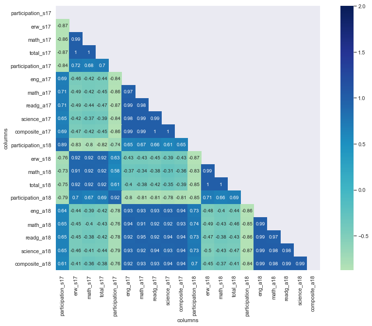

```python
corr_heatmap(final)
```

#### Define a custom function to subplot histograms

[Helpful Link for Plotting Multiple Figures](https://matplotlib.org/users/pyplot_tutorial.html#working-with-multiple-figures-and-axes)

Here's some starter code:

```python
def subplot_histograms(list_of_columns, list_of_titles, list_of_ylabel, list_of_xlabel, dataframe=final):
    nrows = int(np.ceil(len(list_of_columns)/2)) # Makes sure you have enough rows
    fig, ax = plt.subplots(nrows=nrows, ncols=2, figsize=(10, 10)) # You'll want to specify your figsize
    plt.subplots_adjust(wspace=0.2, hspace=0.3) # Format adjustments to subplots
    ax = ax.ravel() # Ravel turns a matrix into a vector, which is easier to iterate
    for i, column in enumerate(list_of_columns): # Gives us an index value to get into all our lists
        ax[i].hist(dataframe[column], color="g", alpha=0.5) # feel free to add more settings
        ax[i].set_title(list_of_titles[i])
        ax[i].set_ylabel(list_of_ylabel[i])
        ax[i].set_xlabel(list_of_xlabel[i])
        # Set titles, labels, etc here for each subplot
    plt.show()
```

#### Plot and interpret histograms

For each of the following:

- Participation rates for SAT & ACT
- Math scores for SAT & ACT
- Reading/verbal scores for SAT & ACT

```python
# Histogram for participation rates
list_of_columns_partn = ["participation_s17", "participation_s18", "participation_a17", "participation_a18"]
list_of_titles_partn = ["participation_s17", "participation_s18", "participation_a17", "participation_a18"]
list_of_ylabel_partn = ["Numbers of participation", "Numbers of participation", "Numbers of participation",
                        "Numbers of participation"
                        ]
list_of_xlabel_partn = ["Participation", "Participation", "Participation", "Participation"]


# Histogram for math scores
list_of_columns_math = ["math_s17", "math_s18", "math_a17", "math_a18"]
list_of_titles_math = ["math_s17", "math_s18", "math_a17", "math_a18"]
list_of_ylabel_math = ["Numbers per math scores", "Numbers per math scores", "Numbers per math scores",
                       "Numbers per math scores"
                       ]
list_of_xlabel_math = ["Math scores", "Math scores", "Math scores", "Math scores"]


# Histogram for reading/verbal scores
list_of_columns_read = ["erw_s17", "erw_s18", "readg_a17", "readg_a18"]
list_of_titles_read = ["erw_s17", "erw_s18", "readg_a17", "readg_a18"]
list_of_ylabel_read = ["Numbers per verbal/reading scores", "Numbers per verbal/reading scores",
                       "Numbers per verbal/reading scores",
                       "Numbers per verbal/reading scores"
                       ]
list_of_xlabel_read = ["verbal/reading scores", "verbal/reading scores", "verbal/reading scores", "verbal/reading scores"]

# Histogram for ACT English and Science scores
list_of_columns_ES = ["eng_a17", "eng_a18", "science_a17", "science_a18"]
list_of_titles_ES = ["eng_a17", "eng_a18", "science_a17", "science_a18"]
list_of_ylabel_ES = ["Numbers per English and Science scores", "Numbers per English and Science scores",
                       "Numbers per English and Science scores",
                       "Numbers per English and Science scores"
                       ]
list_of_xlabel_ES = ["ACT English and Science scores", "ACT English and Science scores scores",
                       "ACT English and Science scores scores", "ACT English and Science scores scores"
                      ]
```

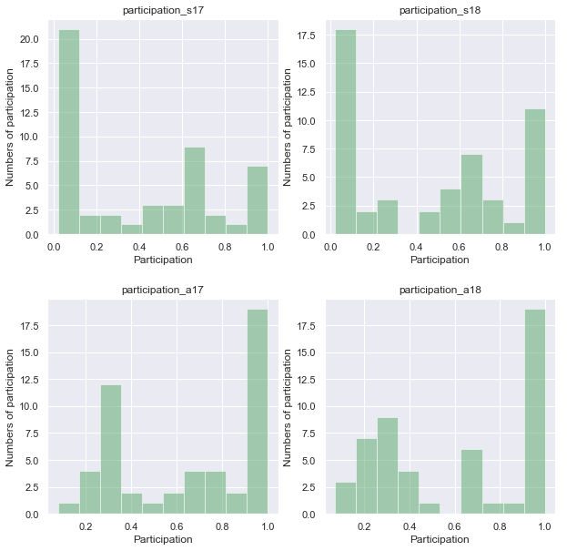

```python
subplot_histograms(list_of_columns_partn, list_of_titles_partn, list_of_ylabel_partn, list_of_xlabel_partn)
```

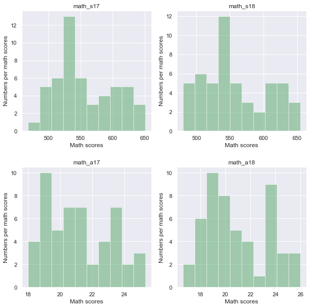

```python
subplot_histograms(list_of_columns_math, list_of_titles_math, list_of_ylabel_math, list_of_xlabel_math)
```

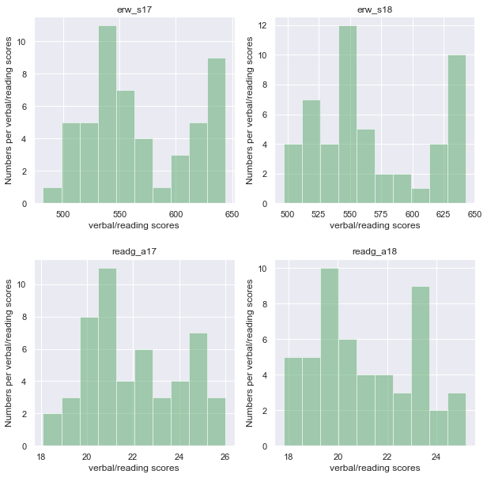

```python
subplot_histograms(list_of_columns_read, list_of_titles_read, list_of_ylabel_read, list_of_xlabel_read)
```

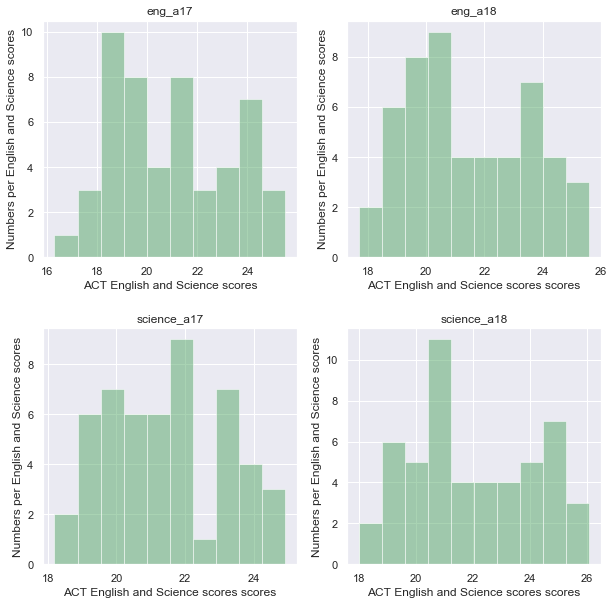

```python
subplot_histograms(list_of_columns_ES, list_of_titles_ES, list_of_ylabel_ES, list_of_xlabel_ES)
```